# Contact Experiment Data Analysis

#!diagnostics suppress=<Extreme1, Extreme2> First Step is to load the necessary package, If you dont have them just install them. For jjstatsplot you need to install it remotely. Just remove the dash and press enter. Then Press 3 (none package to be updated). ?group_by()

```r
#remotes::install_github("sbalci/jjstatsplot") #Press 3 !!!!! i.e., installing/Updating none package!
```

```
There were 12 warnings (use warnings() to see them)
```

```r
library(jmv)
library(datasets)
library(plyr)
library(readr)
library(dataframes2xls)
library(data.table)
library(plyr)
library(ggstatsplot)
library(jjstatsplot)
library(lme4)
library(lmerTest)
library(ggplot2)
library(rstatix)
library(coin)
library(ARTool)
library(ggpubr)
library(tidyverse)
library(dplyr)

#!diagnostics suppress=<Extreme1, Extreme2>
```

Import and merge all the csv files (x.csv where x = ID) of the folder. Note, that the ID is has already been added as column

| ID | Block | TrialInBlock | Trial | InterpenetrationFeedback | FullyShaded | NrOfAdjustments | InterpenetrationTime | TrialTime | FirstContactTime | MaxInterpenetration | AverageInterpenetration | AverageOffsetFromSurface | ReleaseReactionTime | Completed | Attempts | Skipped | RespTime | Age | Gender |
| --- | --- | --- | --- | --- | --- | --- | --- | --- | --- | --- | --- | --- | --- | --- | --- | --- | --- | --- | --- |
| 1 | 0 | 0 | 0 | NoFeedback | FALSE | 1 | 0.7999878 | 11.900670 | 7.2526550 | 0.004603855 | 0.003445460 | 0.023170690 | -2.21130400 | TRUE | 1 | FALSE | 11.876250 | 24 | Male |
| 1 | 0 | 1 | 1 | NoFeedback | TRUE | 0 | 3.2333370 | 7.629913 | 2.8561710 | 0.011058150 | 0.005049573 | 0.006394620 | 0.21545410 | TRUE | 1 | FALSE | 7.602844 | 24 | Male |
| 1 | 0 | 2 | 2 | NoFeedback | TRUE | 0 | 3.5111080 | 7.752625 | 2.6606450 | 0.009252151 | 0.007717762 | 0.004995079 | 0.49606320 | TRUE | 1 | FALSE | 7.725647 | 24 | Male |
| 1 | 0 | 3 | 3 | NoFeedback | FALSE | 0 | 3.5222170 | 7.185577 | 2.2081300 | 0.007552866 | 0.005145890 | 0.006545502 | 0.51058960 | TRUE | 1 | FALSE | 7.157806 | 24 | Male |
| 1 | 0 | 4 | 4 | NoFeedback | TRUE | 0 | 3.5333250 | 6.974274 | 2.0441280 | 0.005565656 | 0.004150445 | 0.006701518 | 0.51391600 | TRUE | 1 | FALSE | 6.947205 | 24 | Male |
| 1 | 0 | 5 | 5 | NoFeedback | FALSE | 0 | 3.6111150 | 9.152069 | 4.1248780 | 0.006274484 | 0.005207492 | 0.010469740 | 0.59445190 | TRUE | 1 | FALSE | 9.125854 | 24 | Male |
| 1 | 0 | 6 | 6 | NoFeedback | FALSE | 0 | 3.6777650 | 10.673000 | 5.6517940 | 0.007548769 | 0.005741521 | 0.008997018 | 0.66598510 | TRUE | 1 | FALSE | 10.647860 | 24 | Male |
| 1 | 0 | 7 | 7 | NoFeedback | FALSE | 0 | 4.1777950 | 7.486664 | 1.8663330 | 0.012234100 | 0.008439113 | 0.002956058 | 1.15805100 | TRUE | 1 | FALSE | 7.430511 | 24 | Male |
| 1 | 0 | 8 | 8 | NoFeedback | TRUE | 0 | 4.1555790 | 7.518311 | 1.9258120 | 0.007320831 | 0.003958890 | 0.011669430 | 1.13925200 | TRUE | 1 | FALSE | 7.493805 | 24 | Male |
| 1 | 0 | 9 | 9 | NoFeedback | TRUE | 0 | 3.7999880 | 13.649660 | 8.4946900 | 0.006290851 | 0.005164649 | 0.010038410 | 0.78967290 | TRUE | 1 | FALSE | 13.622710 | 24 | Male |

[output cut: 990 more lines]

Discard first X trials per interpenetration feedback condition and then create a summary table for each participant. You need to define **nrTrialsPerBlockToRemove**.

```r
nrTrialsPerBlockToRemove <- 1
#trialsToRemove <- seq(from = 1, to = nrTrialsPerBlockToRemove)

  data <-  data %>%
    group_by(ID, Block, InterpenetrationFeedback, FullyShaded) %>% # I have added here the fully shaded
    slice(nrTrialsPerBlockToRemove+1:n())
  # to double check we are discarding the right rows
  #print(data[[i]]$Trial)

 # This df will be used to create the subsets for 1st part and 2nd part of the experiment.

  is.factor(data$InterpenetrationFeedback)
```

```
[1] FALSE
```

```r
  is.factor(data$FullyShaded)
```

```
[1] FALSE
```

```r
  is.numeric(data$InterpenetrationFeedback)
```

```
[1] FALSE
```

```r
data$InterpenetrationFeedback  <- as.factor(data$InterpenetrationFeedback)
data$FullyShaded <- as.factor(data$FullyShaded)
```

#!diagnostics suppress=<Extreme1, Extreme2> Discard unnecessary variables

```r
NewData <- data
#NewData <- select(NewData, -c("Trial", "TrialInBlock", "NrOfAdjustments" , "Completed" , "Attempts" , "Skipped"))
names(NewData)
```

```
 [1] "ID"                       "Block"                    "TrialInBlock"
 [4] "Trial"                    "InterpenetrationFeedback" "FullyShaded"
 [7] "NrOfAdjustments"          "InterpenetrationTime"     "TrialTime"
[10] "FirstContactTime"         "MaxInterpenetration"      "AverageInterpenetration"
[13] "AverageOffsetFromSurface" "ReleaseReactionTime"      "Completed"
[16] "Attempts"                 "Skipped"                  "RespTime"
[19] "Age"                      "Gender"
```

Let’s average the data. This will create 8 (Eight) averaged rows per participant. The logic is 4 Types of interpenetration feedback * 2 Shade conditions (4 x 2 = 8)

```r
Averaged_Data <- aggregate(. ~ ID + Age + Gender + InterpenetrationFeedback + FullyShaded, NewData, mean)


df <- Averaged_Data # A more Convenient name for our dataset
```

#!diagnostics suppress=<Extreme1, Extreme2> Convert from meters to cm

```r
df$MaxInterpenetration <- df$MaxInterpenetration * 100
df$AverageInterpenetration <- df$AverageInterpenetration * 100
df$AverageOffsetFromSurface <- df$AverageOffsetFromSurface * 100
```

Check the distribution of the main dependent variables using histograms

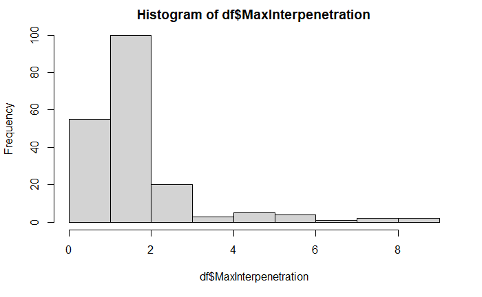

```r
hist(df$MaxInterpenetration)
```

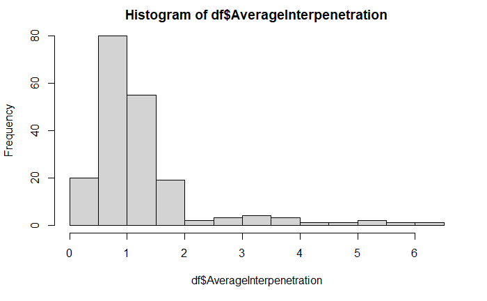

```r
hist(df$AverageInterpenetration)
```

Based on the histograms, the distribution is heavily positively skewed, which is not good, probably we ve violated the normality assumption Let’s check the normality assumption (i.e., whether we have normal distribution or not)

```r
shapiro_test(df$MaxInterpenetration)
```

| variable | statistic | p.value |
| --- | --- | --- |
| df$MaxInterpenetration | 0.658052 | 1.827177e-19 |

```r
shapiro_test(df$AverageInterpenetration)
```

| variable | statistic | p.value |
| --- | --- | --- |
| df$AverageInterpenetration | 0.6752014 | 5.28977e-19 |

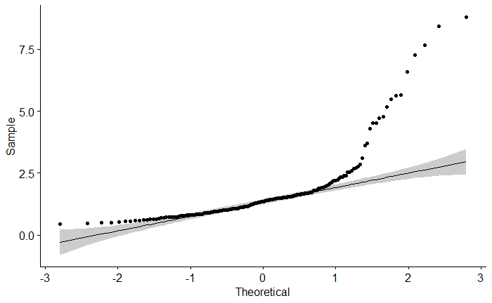

```r
ggqqplot(df$MaxInterpenetration)
```

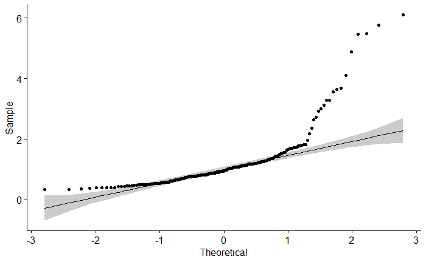

```r
ggqqplot(df$AverageInterpenetration)
```

```r
#Let's check the assumption for each interpenetration feedback and shade condition
df %>%
  group_by(InterpenetrationFeedback, FullyShaded) %>%
  shapiro_test(MaxInterpenetration) #It is violated!
```

| InterpenetrationFeedback | FullyShaded | variable | statistic | p |
| --- | --- | --- | --- | --- |
| Both | FALSE | MaxInterpenetration | 0.5645726 | 2.544870e-07 |
| Both | TRUE | MaxInterpenetration | 0.6642217 | 3.511045e-06 |
| Electrotactile | FALSE | MaxInterpenetration | 0.6986358 | 9.662895e-06 |
| Electrotactile | TRUE | MaxInterpenetration | 0.7842220 | 1.644632e-04 |
| NoFeedback | FALSE | MaxInterpenetration | 0.5914457 | 4.965269e-07 |
| NoFeedback | TRUE | MaxInterpenetration | 0.6016171 | 6.439726e-07 |
| Visual | FALSE | MaxInterpenetration | 0.5664117 | 2.661781e-07 |
| Visual | TRUE | MaxInterpenetration | 0.6741701 | 4.674773e-06 |

```r
df %>%
  group_by(InterpenetrationFeedback, FullyShaded) %>%
  shapiro_test(AverageInterpenetration)  #It is violated!
```

| InterpenetrationFeedback | FullyShaded | variable | statistic | p |
| --- | --- | --- | --- | --- |
| Both | FALSE | AverageInterpenetration | 0.6305820 | 1.381506e-06 |
| Both | TRUE | AverageInterpenetration | 0.6739402 | 4.643685e-06 |
| Electrotactile | FALSE | AverageInterpenetration | 0.7612175 | 7.295244e-05 |
| Electrotactile | TRUE | AverageInterpenetration | 0.8192183 | 6.177214e-04 |
| NoFeedback | FALSE | AverageInterpenetration | 0.5747768 | 3.270021e-07 |
| NoFeedback | TRUE | AverageInterpenetration | 0.5940264 | 5.301884e-07 |
| Visual | FALSE | AverageInterpenetration | 0.6085989 | 7.716155e-07 |
| Visual | TRUE | AverageInterpenetration | 0.6932963 | 8.223819e-06 |

```r
NA
```

#!diagnostics suppress=<Extreme1, Extreme2> OK, we have significant results which means that we have violated the normality assumption (i.e, abnormal distribution). Let’s try to identify the outliers

```r
# One df for outliers (1.5 coeff), one for extremes (3 coeff)
df2 <- df
###############################


df_outliers <- identify_outliers(df, variable = "MaxInterpenetration") #we have several ones
df_outliers2  <- identify_outliers(df, variable = "MaxInterpenetration")


df$Outlier <- is_outlier(df$MaxInterpenetration) #Let's make another variable indicating whether the row is an outlier or not
df$Outlier2 <- is_outlier(df$AverageInterpenetration)

df$Extreme1 <- is_extreme(df$MaxInterpenetration)

df$Extreme2 <- is_extreme(df$AverageInterpenetration)


####### Only extreme values for df2

df_Extremes <- identify_outliers(df, variable = "MaxInterpenetration", coef = 3) #we have several ones
df_Extremes2  <- identify_outliers(df, variable = "MaxInterpenetration", coef = 3)

df2$Extreme1 <- is_extreme(df2$MaxInterpenetration)

df2$Extreme2 <- is_extreme(df2$AverageInterpenetration)
```

#!diagnostics suppress=<Extreme1, Extreme2> Let’s try to solve it by omitting the outliers

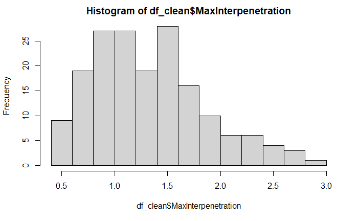

```r
df$Outlier[df$Outlier == TRUE]  <- NA
df$Outlier2[df$Outlier2 == TRUE]  <- NA

df_clean <- na.omit(df) #We omit the rows which have NA values !!! and we create a new dataset without outliers.

#we check again the histograms, qqplots, and normality assumption
hist(df_clean$MaxInterpenetration)
```

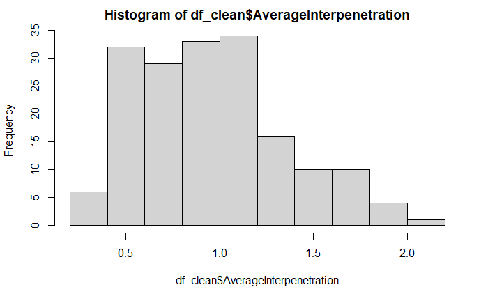

```r
hist(df_clean$AverageInterpenetration) #better than before but stil skewed
```

```r
shapiro_test(df_clean$MaxInterpenetration)
```

| variable | statistic | p.value |
| --- | --- | --- |
| df_clean$MaxInterpenetration | 0.9567695 | 3.235895e-05 |

```r
shapiro_test(df_clean$AverageInterpenetration) # violated!
```

| variable | statistic | p.value |
| --- | --- | --- |
| df_clean$AverageInterpenetration | 0.9617015 | 0.0001003668 |

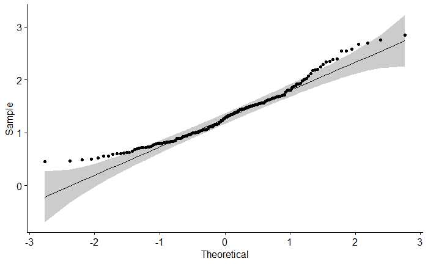

```r
ggqqplot(df_clean$MaxInterpenetration)
```

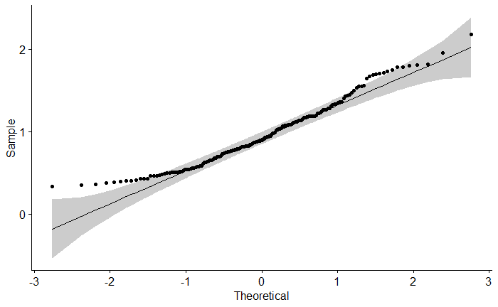

```r
ggqqplot(df_clean$AverageInterpenetration) #qqplots are good.
```

```r
df_clean %>%
  group_by(InterpenetrationFeedback, FullyShaded) %>%
  shapiro_test(MaxInterpenetration) #Still some violate the assumption
```

| InterpenetrationFeedback | FullyShaded | variable | statistic | p |
| --- | --- | --- | --- | --- |
| Both | FALSE | MaxInterpenetration | 0.9107163 | 0.042290560 |
| Both | TRUE | MaxInterpenetration | 0.9323559 | 0.122963637 |
| Electrotactile | FALSE | MaxInterpenetration | 0.9779991 | 0.894161937 |
| Electrotactile | TRUE | MaxInterpenetration | 0.9635148 | 0.616191236 |
| NoFeedback | FALSE | MaxInterpenetration | 0.9862069 | 0.983498410 |
| NoFeedback | TRUE | MaxInterpenetration | 0.9731004 | 0.781612051 |
| Visual | FALSE | MaxInterpenetration | 0.8381965 | 0.002114225 |
| Visual | TRUE | MaxInterpenetration | 0.9027144 | 0.033696724 |

```r
df_clean %>%
  group_by(InterpenetrationFeedback, FullyShaded) %>%
  shapiro_test(AverageInterpenetration) #Still some violate the assumption
```

| InterpenetrationFeedback | FullyShaded | variable | statistic | p |
| --- | --- | --- | --- | --- |
| Both | FALSE | AverageInterpenetration | 0.9221928 | 0.074238873 |
| Both | TRUE | AverageInterpenetration | 0.9321515 | 0.121719385 |
| Electrotactile | FALSE | AverageInterpenetration | 0.9756153 | 0.851062820 |
| Electrotactile | TRUE | AverageInterpenetration | 0.9770670 | 0.890889087 |
| NoFeedback | FALSE | AverageInterpenetration | 0.9397774 | 0.195847285 |
| NoFeedback | TRUE | AverageInterpenetration | 0.9800093 | 0.916139731 |
| Visual | FALSE | AverageInterpenetration | 0.8599993 | 0.005127411 |
| Visual | TRUE | AverageInterpenetration | 0.8896176 | 0.018528342 |

```r
################# Let's do the same just only for the extreme values

df2$Extreme1[df2$Extreme1 == TRUE]  <- NA
df2$Extreme2[df2$Extreme2 == TRUE]  <- NA

df2_clean <- na.omit(df2) #We omit the rows which have NA values !!! and we create a new dataset without outliers.


df2_clean %>%
  group_by(InterpenetrationFeedback, FullyShaded) %>%
  shapiro_test(MaxInterpenetration) #Still some violate the assumption
```

| InterpenetrationFeedback | FullyShaded | variable | statistic | p |
| --- | --- | --- | --- | --- |
| Both | FALSE | MaxInterpenetration | 0.9107163 | 4.229056e-02 |
| Both | TRUE | MaxInterpenetration | 0.9323559 | 1.229636e-01 |
| Electrotactile | FALSE | MaxInterpenetration | 0.9779991 | 8.941619e-01 |
| Electrotactile | TRUE | MaxInterpenetration | 0.8731219 | 8.953191e-03 |
| NoFeedback | FALSE | MaxInterpenetration | 0.9862069 | 9.834984e-01 |
| NoFeedback | TRUE | MaxInterpenetration | 0.9731004 | 7.816121e-01 |
| Visual | FALSE | MaxInterpenetration | 0.7585124 | 8.912687e-05 |
| Visual | TRUE | MaxInterpenetration | 0.9027144 | 3.369672e-02 |

```r
df2_clean %>%
  group_by(InterpenetrationFeedback, FullyShaded) %>%
  shapiro_test(AverageInterpenetration) #Still some violate the assumption
```

| InterpenetrationFeedback | FullyShaded | variable | statistic | p |
| --- | --- | --- | --- | --- |
| Both | FALSE | AverageInterpenetration | 0.9221928 | 0.0742388727 |
| Both | TRUE | AverageInterpenetration | 0.9321515 | 0.1217193852 |
| Electrotactile | FALSE | AverageInterpenetration | 0.9756153 | 0.8510628196 |
| Electrotactile | TRUE | AverageInterpenetration | 0.8650858 | 0.0063499819 |
| NoFeedback | FALSE | AverageInterpenetration | 0.9397774 | 0.1958472849 |
| NoFeedback | TRUE | AverageInterpenetration | 0.9800093 | 0.9161397313 |
| Visual | FALSE | AverageInterpenetration | 0.8071640 | 0.0005000268 |
| Visual | TRUE | AverageInterpenetration | 0.8896176 | 0.0185283420 |

```r
NA
```

OK the distribution is better now but again it violates the normality assumption